[figure not shown]

[figure not shown]

# Introduction à l’halieutique

La pêche, une activité humaine

Laurent Dubroca

23/11/2026

## Plan

1. **Qu’est-ce que la pêche ?** Définitions et ordres de grandeur
2. **Une longue histoire** : de la préhistoire à la pêche industrielle
3. **À quoi sert la pêche ?** Se nourrir, vivre, commercer, se divertir
4. **Les engins de pêche** : comment les humains capturent les ressources aquatiques

## Qu’est-ce que la pêche ?

01.

Définitions et ordres de grandeur

## Quelques définitions

- **Pêche** : capture d’animaux aquatiques (poissons, crustacés, mollusques…) dans leur milieu naturel, en mer ou en eau douce
- **Aquaculture** : *élevage* d’organismes aquatiques. La pêche est un *prélèvement* sur une ressource sauvage
- **Captures** : quantités prélevées dans le milieu ; **débarquements** : quantités ramenées à terre
- **Halieutique** : science de l’exploitation des ressources vivantes aquatiques, l’équivalent de l’agronomie pour les milieux aquatiques

**Halieutique**, du grec *halieutikos* : « qui concerne la pêche ».

Les *Halieutiques* d’Oppien (IIe siècle) décrivent déjà plus de 120 poissons et de nombreuses techniques de pêche (Le Loc’h 2019).

Ce cours porte sur les **pêches maritimes**.

## La pêche et l’aquaculture dans le monde

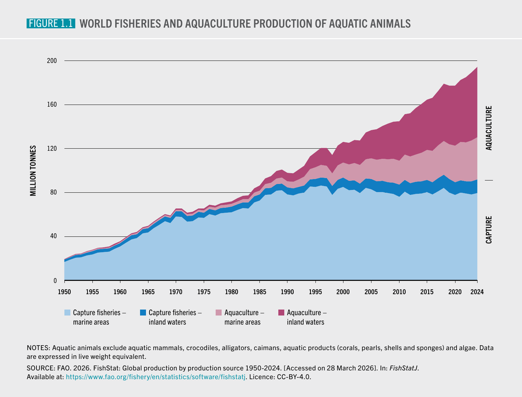

En 2024 (FAO 2026, 2024) :

- **235 Mt** produites, dont **195 Mt** d’animaux aquatiques
- **Pêche : 92 Mt**, stable depuis la fin des années 1980 (entre 86 et 94 Mt)
- **Aquaculture : 103 Mt**, soit **53 %** des animaux aquatiques : elle dépasse la pêche depuis 2022
- **4,7 millions** de navires de pêche
- **65 millions** d’emplois dans la production

## Une longue histoire

02.

De la préhistoire à la pêche industrielle

## Aux origines : la préhistoire

| Âge | Site | Indice |
| --- | --- | --- |
| ~106 000–86 000 ans | Figueira Brava (Portugal) | Néandertaliens consommant poissons, crabes, mollusques (Zilhão et al. 2020) |
| ~90 000 ans | Katanda (RD Congo) | pointes en os barbelées, restes de poissons-chats (Yellen et al. 1995) |
| ~42 000 ans | Jerimalai (Timor oriental) | poissons pélagiques du large ; un hameçon plus récent, ~23 000–16 000 ans (O’Connor et al. 2011) |
| ~23 000 ans | Sakitari (Okinawa) | hameçons en coquillage (Fujita et al. 2016) |

**La pêche est l’une des plus anciennes activités humaines.**

Elle précède l’agriculture et l’élevage de plusieurs dizaines de milliers d’années.

Les datations les plus anciennes restent discutées.

## L’Antiquité : techniques et commerce

- **Égypte** (~3000 av. J.-C.) : harpons, lignes à plusieurs hameçons, nasses, **filets** tirés par des équipes d’hommes
- **Méditerranée** : guet et capture du **thon rouge** en migration ; ces pêches donneront plus tard les **madragues** (*almadrabas*), encore utilisées en Espagne et en Sardaigne
- **Rome** : sennes, éperviers, filets maillants, engins traînants proches du chalut ; viviers ; commerce du poisson salé et du *garum*

**La conservation change tout**

Séchage, salage, fumage, fermentation : le poisson devient une **marchandise** transportable et échangeable.

## Moyen Âge : hareng et morue

- Vers **l’an 1000** en Angleterre : forte augmentation des captures marines de hareng et de morue, le « *fish event horizon* » (Barrett et al. 2004)
- **Hareng** : la **Ligue hanséatique** (XIIIe siècle) organise les campagnes, la conservation, le transport et la vente
- **Morue** : de la Norvège à l’Islande, puis **Terre-Neuve** (XVIe siècle). En 1573, 330 navires y pêchent, dont 150 français (Le Loc’h 2019)

> « La morue, à elle seule, a créé des colonies, fondé des comptoirs et des villes. »

> Jules Michelet, *La Mer* (1861), cité par Le Loc’h (2019)

Hareng et morue sont les **premières pêcheries de masse** et la base d’une **économie maritime** européenne.

## La révolution industrielle

- **XIXe siècle** : conserve, chemin de fer et glace élargissent les marchés
- **Fin du XIXe** : les **chalutiers à vapeur** remplacent la voile ; la pêche ne dépend plus du vent
- **XXe siècle** : moteur diesel, fibres synthétiques, sondeurs, congélation à bord ; flottes de **pêche lointaine** après 1945 (URSS, Japon, Espagne…)
- **1950 → 1990** : les captures mondiales passent d’environ 20 à 90 Mt

**Un rendement qui s’effondre**

Au Royaume-Uni, les débarquements des chalutiers de fond **par unité de puissance de pêche** ont baissé de **94 %** en 118 ans (1889-2007) (Thurstan et al. 2010).

## Liberté des mers et appropriation

**Grotius**, *Mare liberum* (1609) : la mer est libre, et ses richesses sont trop abondantes pour être épuisées (idée résumée)

- Jusqu’aux années 1970 : accès quasi libre au large ; premières revendications à 200 milles par le Chili et le Pérou dès 1947-1952
- **Zone économique exclusive (ZEE)** de 200 milles, négociée à partir de 1973 et inscrite dans la **Convention de Montego Bay** (1982)
- ~90 % des pêcheries passent sous le contrôle des États côtiers (Le Loc’h 2019)

**La « tragédie des communs »**

Quand une ressource est en accès libre, chacun a intérêt à capturer le plus possible avant les autres, même si tous y perdent à terme (Hardin 1968).

C’est l’un des fondements de la **gestion des pêches**.

## Effondrements et prise de conscience

**La morue de Terre-Neuve**

- Captures maximales à la fin des années 1960 (~800 000 t), puis déclin (Le Loc’h 2019)
- **2 juillet 1992** : moratoire sur la pêche de la morue du Nord (Hutchings et Myers 1994)
- ~30 000 emplois perdus à Terre-Neuve ; stock toujours très bas dix ans plus tard (Hutchings et Reynolds 2004)

**Les baleines** : jusqu’à 50 000 captures par an dans les années 1930, moratoire commercial en 1986 (Le Loc’h 2019)

**Des concepts clés**

- **Référentiel glissant** (*shifting baseline*) : chaque génération prend pour « normal » l’état qu’elle a connu (Pauly 1995)
- **Pêche vers le bas des réseaux trophiques** : la pêche se reporte vers des espèces plus petites, de niveau trophique plus bas (Pauly et al. 1998)
- La surpêche a précédé les autres perturbations des écosystèmes côtiers (Jackson et al. 2001)

## Deux siècles de pressions sur l’océan

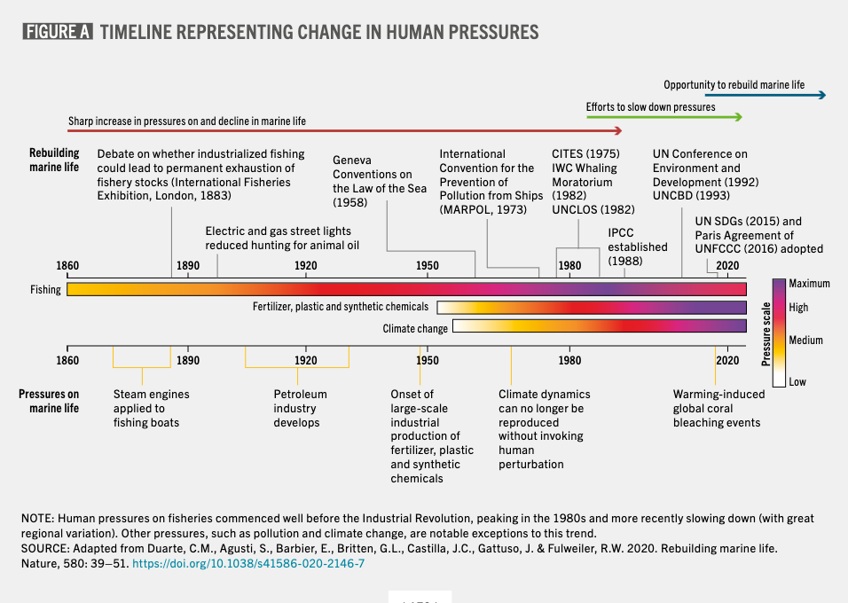

Source : Duarte et al. (2020), reproduit par la FAO

## À quoi sert la pêche ?

03.

Se nourrir, vivre, commercer, se divertir

## D’abord, nourrir

- **89 %** de la production d’animaux aquatiques est destinée à l’alimentation humaine ; le reste devient surtout **farine et huile** de poisson
- **21,3 kg** par habitant et par an en 2024 : de 9,1 kg en Afrique à 26,3 kg en Asie
- Au moins **20 %** des protéines animales pour **3,1 milliards** de personnes
- En Afrique : peu consommé en quantité, mais **19 %** des protéines animales

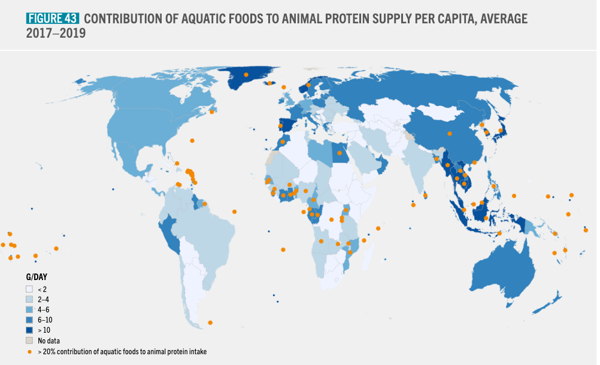

Apport en protéines animales issues des produits aquatiques, 2017-2019 (FAO 2022)

## Vivre de la pêche : de la subsistance à l’industrie

**Pêche de subsistance et petite échelle**

- Au moins **40 %** des captures mondiales
- **60 millions** d’emplois sur toute la filière (capture, transformation, vente), environ **90 %** de l’emploi lié à la pêche (FAO et al. 2023)
- Pirogues, petits navires, pêche à pied ; souvent mal recensée
- Les **femmes** : 27 % des emplois de production, 56 % dans la transformation (FAO 2026)

**Pêche industrielle**

- Grands navires, forte puissance, pêche au large ou lointaine
- Peu d’emplois par tonne capturée, gros volumes, souvent destinés à l’export ou à la transformation

**France hexagonale (2024)** : 4 052 navires, **10,6 m** de longueur moyenne, 8 585 marins (Ifremer – Système d’Informations Halieutiques 2026)

## Commercer : un marché mondial

- **186 milliards USD** d’échanges en 2024, **230** pays et territoires (FAO 2026)
- Environ **36 %** de la production mondiale est exportée
- Une valeur comparable à celle du commerce mondial de viande
- Premiers exportateurs : Chine, Norvège, Viêt Nam, Équateur, Chili
- Premier marché : l’**Union européenne** (63 milliards USD d’importations)

**Une Europe dépendante**

L’Union européenne ne produit que **38 %** des produits de la mer qu’elle consomme (2021) (Commission européenne 2024).

**Pêche illicite, non déclarée et non réglementée** (INN) : environ **10 milliards €** par an, près de 20 % de la valeur des captures mondiales (Commission européenne 2024)

## Se divertir : la pêche de loisir

**En Europe** (Hyder et al. 2018)

- **8,7 millions** de pêcheurs de loisir en mer
- 77,6 millions de jours de pêche par an
- **5,9 milliards €** de dépenses par an

**Dans le monde** : environ **12 %** des captures, ordre de grandeur à prendre avec prudence (Cooke et Cowx 2004)

**En France métropolitaine** (FranceAgriMer et BVA 2018)

- **2,7 millions** de pêcheurs de loisir en mer (15 ans et plus)
- dont **1,5 million** pratiquent uniquement la **pêche à pied**

Le **bar** est l’espèce la plus capturée **en poids** par les pêcheurs de loisir : environ **4 000 t** conservées par an (Ifremer 2013)

## Les autres usages de la pêche

- **Farine et huile de poisson** : aliments pour l’aquaculture et l’élevage
- **Appâts**, aquariophilie, cosmétique, pharmacie
- **Identité culturelle** des territoires littoraux : ports, criées, fêtes, savoir-faire, patrimoine
- **Tourisme** : ports de pêche, vente directe, gastronomie

**Un système socio-écologique**

La pêche relie une **ressource** (les populations exploitées), des **usagers** (pêcheurs, transformateurs, consommateurs) et des **règles** (accès, quotas, engins).

L’halieutique étudie les trois.

## Les engins de pêche

04.

Comment les humains capturent les ressources aquatiques

## Un peu de vocabulaire

**Où vivent les espèces ?**

- **Pélagique** : en pleine eau (sardine, thon, maquereau)
- **Démersal** : près du fond, sans en dépendre totalement (cabillaud, merlu)
- **Benthique** : sur ou dans le fond (sole, coquille Saint-Jacques) ; le **benthos** désigne l’ensemble des organismes du fond

**Stock** : unité de gestion d’une population exploitée

**Que capture-t-on ?**

- **Sélectivité** : capacité d’un engin à ne capturer que les tailles et espèces visées
- **Captures accessoires** : espèces capturées sans être ciblées
- **Rejets** : captures remises à la mer
- **Effort de pêche** : quantité de pêche déployée (jours de mer, nombre d’hameçons…)
- **Quota / TAC** : quantité maximale autorisée à la capture

## Engins actifs et engins passifs

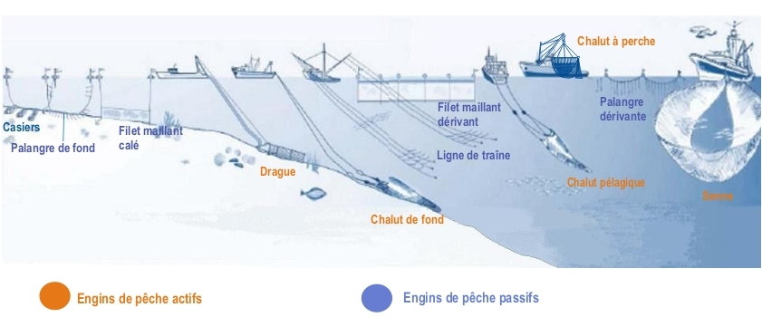

**Engins actifs** : l’engin va **chercher** le poisson (chaluts, dragues, sennes)

**Engins passifs** : le poisson **vient à l’engin** (filets maillants, palangres, casiers)

## La classification internationale des engins

La FAO classe les engins selon leur **mode de capture** (ISSCFG, révision 2016) (FAO et CWP 2016) :

| Groupe | Principe | Exemples |
| --- | --- | --- |
| **Filets tournants** | encerclent un banc | senne coulissante (thon, sardine) |
| **Sennes** | filet tiré vers la plage ou le navire | senne de plage, senne danoise |
| **Chaluts** | filet en forme de poche tracté | chalut de fond, chalut pélagique |
| **Dragues** | armature raclant le fond | drague à coquille Saint-Jacques |
| **Filets soulevés / retombants** | filet relevé ou lancé sur le poisson | carrelet, épervier |
| **Filets maillants et emmêlants** | le poisson s’emmaille dans le filet | filet droit, trémail |
| **Pièges** | le poisson entre et ne ressort pas | casiers, nasses, madragues |
| **Lignes et hameçons** | appât ou leurre sur hameçon | palangre, ligne à main, canne, traîne |
| **Grappins et engins blessants** | l’animal est saisi ou transpercé | harpon, foëne |
| **Machines de récolte** | aspiration ou récolte mécanique | pompes à poissons, récolteuses |
| **Divers** |  | pêche à pied, à la main, en plongée |

## Les engins traînants : chaluts et dragues

**Chalut** : filet en forme d’entonnoir, terminé par une poche (le **cul de chalut**), tracté par un ou deux navires

- **de fond** : maintenu ouvert par des panneaux ou une perche ; poissons plats, merlu, langoustines…
- **pélagique** : en pleine eau ; hareng, maquereau, anchois…

**Drague** : cadre métallique muni de dents, tracté sur le fond ; **coquille Saint-Jacques**

**Impact sur les fonds** (Hiddink et al. 2017)

À chaque passage :

- chalut à panneaux : **6 %** du benthos retiré, pénétration de 2,4 cm
- drague hydraulique : **41 %** retiré, pénétration de 16 cm
- récupération : 1,9 à 6,4 ans

## Encercler : les sennes

- **Senne coulissante** (filet tournant) : un grand filet entoure un banc repéré au sondeur ou à vue, puis se referme par le bas comme une bourse
  - thons tropicaux, sardines, anchois, maquereaux
  - les plus gros volumes de captures mondiaux (anchois du Pérou)
- **Senne de plage** : filet déployé depuis le rivage puis halé à terre
- **Senne danoise ou écossaise** : longs cordages qui rabattent le poisson démersal vers le filet

**Dispositifs de concentration de poissons (DCP)**

Objets flottants qui attirent les thons tropicaux et facilitent la pêche à la senne, mais augmentent les **captures de juvéniles** et d’espèces non ciblées.

## Les engins passifs : filets, lignes et pièges

**Filets maillants**

- nappe verticale posée sur le fond ou dérivante
- **trémail** : trois nappes superposées
- sole, bar, rouget, cabillaud
- **sélectifs en taille** par le maillage

**Lignes et hameçons**

- **palangre** : ligne mère portant des centaines ou des milliers d’hameçons
- ligne à main, canne, traîne
- thon, espadon, merlu, bar
- poisson de **qualité**, peu d’impact sur le fond

**Pièges**

- **casiers et nasses** : homard, tourteau, araignée, **bulot**, seiche
- **pêcheries fixes**, madragues
- captures vivantes : on peut **relâcher** les individus non désirés

Chaque engin a ses atouts et ses limites : **sélectivité**, **captures accessoires** (mammifères, oiseaux), **impact sur les habitats**, **consommation de carburant**.

## De l’engin au métier

Un **métier** = un **engin** + une ou des **espèces cibles** + une **zone** + une **période**

Exemples en Manche :

- dragueur à **coquille Saint-Jacques** en baie de Seine (dates fixées chaque année, environ d’octobre à mi-mai)
- chalutier de fond à **poissons démersaux**
- caseyeur à **bulot** dans le golfe normand-breton
- fileyeur à **sole**

Un même navire peut pratiquer **plusieurs métiers** dans l’année.

Le métier est l’unité de base pour **suivre l’activité** des flottilles et **gérer** les pêcheries.

Le Système d’Informations Halieutiques de l’Ifremer reconstitue chaque année le calendrier des métiers de tous les navires français (Ifremer – Système d’Informations Halieutiques 2026).

## À retenir

- La pêche est l’une des **plus anciennes activités humaines** ; son **industrialisation** depuis le XIXe siècle a fortement réduit l’abondance de nombreuses ressources
- Les captures mondiales **stagnent** autour de 90 Mt depuis la fin des années 1980 ; l’**aquaculture** assure désormais la croissance
- La pêche **nourrit** (20 % des protéines animales pour 3 milliards de personnes), **emploie** (surtout la petite échelle), alimente un **commerce mondial** et des **loisirs**
- Les **engins** (actifs ou passifs) déterminent les espèces capturées, la sélectivité et les impacts sur l’écosystème
- **Ressource commune** et **référentiel glissant** : la pêche doit être **gérée**, et cette gestion repose sur des **données**

## Vers le TD 3

**Analyse descriptive des débarquements d’une espèce en Manche Est** (`applications/03_peche_application.qmd`)

| Partie du TD | Ce que vous ferez | Notions du cours |
| --- | --- | --- |
| Découvrir les données | lire et explorer les débarquements, les référentiels et les couches cartographiques | données de pêche, secret statistique |
| Choisir une espèce | repérer les espèces les plus débarquées en Manche Est | ressources exploitées, vocabulaire |
| Évolution annuelle | tracer les débarquements de 2000 à 2025 | industrialisation, référentiel glissant |
| Par engin | comparer les engins qui débarquent l’espèce | engins actifs et passifs, classification FAO |
| Cartographie | cartographier les débarquements par rectangle statistique | zones de pêche, métiers |
| Capture par unité d’effort | calculer des kilos par marée, engin par engin | effort de pêche, sélectivité |

Données : débarquements des navires français en Manche Est (SIH Ifremer). Packages : **ggplot2** et **sf**.

## Références

Barrett, James H., Alison M. Locker, et Callum M. Roberts. 2004. « The Origins of Intensive Marine Fishing in Medieval Europe: The English Evidence ». *Proceedings of the Royal Society of London. Series B: Biological Sciences* 271 (1556): 2417‑21. https://doi.org/10.1098/rspb.2004.2885.

Commission européenne. 2024. *La politique commune de la pêche en chiffres : données statistiques de base, édition 2024*. KL-01-24-001-FR-N. Office des publications de l’Union européenne.

Cooke, Steven J., et Ian G. Cowx. 2004. « The Role of Recreational Fishing in Global Fish Crises ». *BioScience* 54 (9): 857‑59. https://doi.org/10.1641/0006-3568(2004)054[0857:TRORFI]2.0.CO;2.

Cury, Philippe, et Yves Miserey. 2008. *Une mer sans poissons*. Calmann-Lévy.

Duarte, Carlos M., Susana Agusti, Edward Barbier, et al. 2020. « Rebuilding Marine Life ». *Nature* 580 (7801): 39‑51. https://doi.org/10.1038/s41586-020-2146-7.

FAO. 2022. *The State of World Fisheries and Aquaculture 2022. Towards Blue Transformation*. FAO. https://doi.org/10.4060/cc0461en.

FAO. 2024. *The State of World Fisheries and Aquaculture 2024. Blue Transformation in Action*. FAO. https://doi.org/10.4060/cd0683en.

FAO. 2026. *The State of World Fisheries and Aquaculture 2026*. FAO. https://doi.org/10.4060/cd8357en.

FAO, et CWP. 2016. *International Standard Statistical Classification of Fishing Gear (ISSCFG, Rev.1), adoptée à la 25e session du CWP*. CWP Handbook of Fishery Statistics, Annex M. https://www.fao.org/cwp-on-fishery-statistics/handbook/capture-fisheries-statistics/fishing-gear-classification/en/.

FAO, Duke University, et WorldFish. 2023. *Illuminating Hidden Harvests: The Contributions of Small-Scale Fisheries to Sustainable Development*. FAO. https://doi.org/10.4060/cc4576en.

FranceAgriMer, et BVA. 2018. *Évaluation de l’activité de pêche de loisirs en France métropolitaine (dont la Corse). Enquête de cadrage – novembre/décembre 2017*. Les études de FranceAgriMer. FranceAgriMer. https://sextant.ifremer.fr/sextant_data/DCSMM_EVAL2024/SOURCES/FRANCEAGRIMER/859_franceagrimer_etude_peche_loisir_2018.pdf.

Fujita, Masaki, Shinji Yamasaki, Chiaki Katagiri, et al. 2016. « Advanced Maritime Adaptation in the Western Pacific Coastal Region Extends Back to 35,000–30,000 Years before Present ». *Proceedings of the National Academy of Sciences* 113 (40): 11184‑89. https://doi.org/10.1073/pnas.1607857113.

Gabriel, Otto, Klaus Lange, Erdmann Dahm, et Thomas Wendt, éd. 2005. *Von Brandt’s Fish Catching Methods of the World*. 4ᵉ éd. Blackwell Publishing.

Gascuel, Didier. 2019. *Pour une révolution dans la mer. De la surpêche à la résilience*. Actes Sud.

Hardin, Garrett. 1968. « The Tragedy of the Commons ». *Science* 162 (3859): 1243‑48. https://doi.org/10.1126/science.162.3859.1243.

Hiddink, Jan Geert, Simon Jennings, Marija Sciberras, et al. 2017. « Global Analysis of Depletion and Recovery of Seabed Biota after Bottom Trawling Disturbance ». *Proceedings of the National Academy of Sciences* 114 (31): 8301‑6. https://doi.org/10.1073/pnas.1618858114.

Hutchings, Jeffrey A., et Ransom A. Myers. 1994. « What Can Be Learned from the Collapse of a Renewable Resource? Atlantic Cod, *Gadus morhua*, of Newfoundland and Labrador ». *Canadian Journal of Fisheries and Aquatic Sciences* 51 (9): 2126‑46. https://doi.org/10.1139/f94-214.

Hutchings, Jeffrey A., et John D. Reynolds. 2004. « Marine Fish Population Collapses: Consequences for Recovery and Extinction Risk ». *BioScience* 54 (4): 297‑309. https://doi.org/10.1641/0006-3568(2004)054[0297:MFPCCF]2.0.CO;2.

Hyder, Kieran, Marc Simon Weltersbach, Mike Armstrong, et al. 2018. « Recreational Sea Fishing in Europe in a Global Context—Participation Rates, Fishing Effort, Expenditure, and Implications for Monitoring and Assessment ». *Fish and Fisheries* 19 (2): 225‑43. https://doi.org/10.1111/faf.12251.

Ifremer. 2013. *La pêche récréative en mer en France métropolitaine (Atlantique, Manche, Mer du Nord, Méditerranée). Résultats de l’enquête 2011–2013*. Plaquette de synthèse, Ifremer / BVA. https://sextant.ifremer.fr/sextant_data/DCSMM_EVAL2018/SOURCES/UNIV_BREST/AES/PECHE_LOISIR/Ifremer_P%c3%aache%20r%c3%a9cr%c3%a9ative.pdf.

Ifremer – Système d’Informations Halieutiques. 2026. *Synthèse de la flotte 2024 – France hexagonale*. Synthèse SIH. Ifremer. https://sih.ifremer.fr.

Jackson, Jeremy B. C., Michael X. Kirby, Wolfgang H. Berger, et al. 2001. « Historical Overfishing and the Recent Collapse of Coastal Ecosystems ». *Science* 293 (5530): 629‑37. https://doi.org/10.1126/science.1059199.

Le Loc’h, François. 2019. *Introduction à l’halieutique et aux pêcheries marines*. Support de cours, Master 2, UMR LEMAR / IRD, Brest.

O’Connor, Sue, Rintaro Ono, et Chris Clarkson. 2011. « Pelagic Fishing at 42,000 Years Before the Present and the Maritime Skills of Modern Humans ». *Science* 334 (6059): 1117‑21. https://doi.org/10.1126/science.1207703.

Olsen, Esben M., Mikko Heino, George R. Lilly, et al. 2004. « Maturation Trends Indicative of Rapid Evolution Preceded the Collapse of Northern Cod ». *Nature* 428 (6986): 932‑35. https://doi.org/10.1038/nature02430.

Pauly, Daniel. 1995. « Anecdotes and the Shifting Baseline Syndrome of Fisheries ». *Trends in Ecology & Evolution* 10 (10): 430. https://doi.org/10.1016/S0169-5347(00)89171-5.

Pauly, Daniel, Villy Christensen, Johanne Dalsgaard, Rainer Froese, et Francisco Torres. 1998. « Fishing Down Marine Food Webs ». *Science* 279 (5352): 860‑63. https://doi.org/10.1126/science.279.5352.860.

Pauly, Daniel, et Dirk Zeller. 2016. « Catch Reconstructions Reveal That Global Marine Fisheries Catches Are Higher than Reported and Declining ». *Nature Communications* 7: 10244. https://doi.org/10.1038/ncomms10244.

Thurstan, Ruth H., Simon Brockington, et Callum M. Roberts. 2010. « The Effects of 118 Years of Industrial Fishing on UK Bottom Trawl Fisheries ». *Nature Communications* 1: 15. https://doi.org/10.1038/ncomms1013.

Yellen, John E., Alison S. Brooks, Els Cornelissen, Michael J. Mehlman, et Kathlyn Stewart. 1995. « A Middle Stone Age Worked Bone Industry from Katanda, Upper Semliki Valley, Zaire ». *Science* 268 (5210): 553‑56. https://doi.org/10.1126/science.7725100.

Zilhão, João, Diego E. Angelucci, Marina Araújo Igreja, et al. 2020. « Last Interglacial Iberian Neandertals as Fisher-Hunter-Gatherers ». *Science* 367 (6485): eaaz7943. https://doi.org/10.1126/science.aaz7943.